# Lecture 16: DBSCAN and Hierarchical Clustering

from

> https://github.com/UBC-CS/cpsc330

## Recap and motivation

### K-Means recap

- We discussed K-Means clustering in the previous lecture.
- Each cluster is represented by a center.
- Given a new point, you can assign it to a cluster by computing the distances to all cluster centers and picking the cluster with the smallest distance.
- It's a popular algorithm because
  - It's easy to understand and implement.
  - Runs relatively quickly and scales well to large datasets.
  - `sklearn` has a more scalable variant called [`MiniBatchKMeans`](https://scikit-learn.org/stable/modules/generated/sklearn.cluster.MiniBatchKMeans.html) which can handle very large datasets.

### K-Means limitations

- Relies on random initialization and so the outcome may change depending upon this initialization.
- K-Means clustering requires to specify the number of clusters in advance.
- Very often you do not know the centers in advance. The elbow method or the silhouette method to find the optimal number of clusters are not always easy to interpret.
- Each point has to have a cluster assignment.

### K-Means limitations: Shape of K-Means clusters

- K-Means partitions the space based on the closest mean.
- Each cluster is defined solely by its center and so it can only capture relatively simple shapes.
- So the boundaries between clusters are linear; It fails to identify clusters with complex shapes. [Source](https://scikit-learn.org/stable/auto_examples/cluster/plot_kmeans_digits.html).

[figure not shown]

### K-Means: failure case 1

- K-Means performs poorly if the clusters have more complex shapes (e.g., two moons data below).

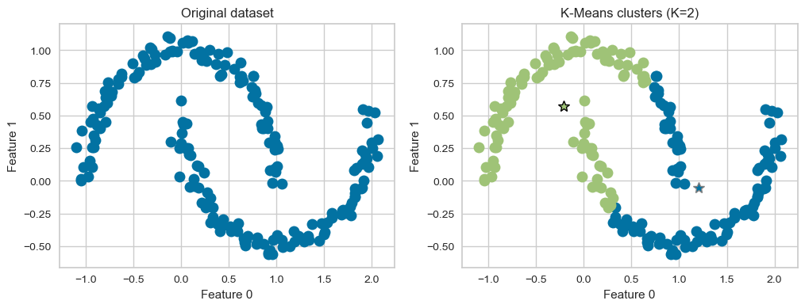

```python
X, y = make_moons(n_samples=200, noise=0.05, random_state=42)
plot_X_k_means(X, k=2)
```

### K-Means: failure case 2

- It assumes that all directions are equally important for each cluster and fails to identify non-spherical clusters.

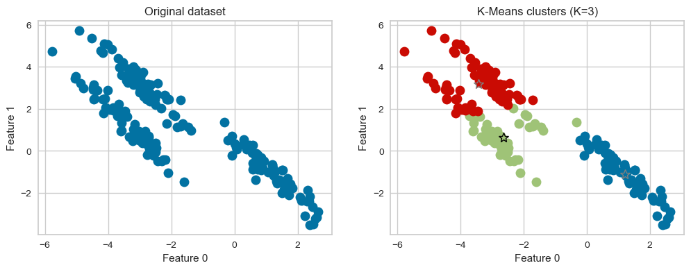

```python
# generate some random cluster data
X, y = make_blobs(random_state=170, n_samples=200)
rng = np.random.RandomState(74)
transformation = rng.normal(size=(2, 2))
X = np.dot(X, transformation)
plot_X_k_means(X, 3)
```

### K-Means: failure case 3

- Again, K-Means is unable to capture complex cluster shapes.

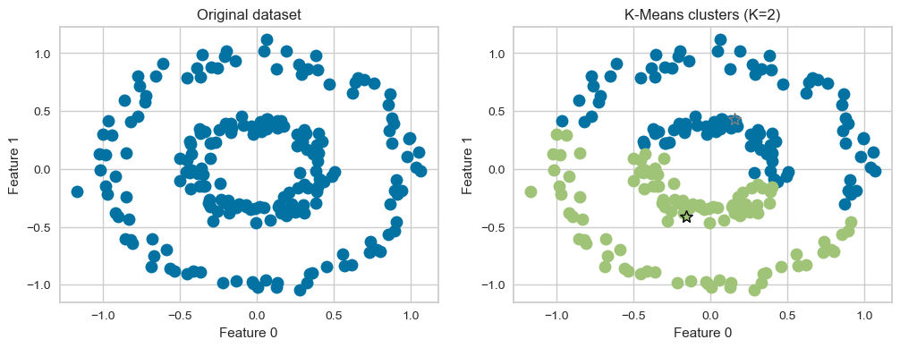

```python
X = datasets.make_circles(n_samples=200, noise=0.06, factor=0.4)[0]
plot_X_k_means(X, 2)
```

- Can we do better than this?
- Another clustering algorithm called DBSCAN is able to tackle some of these cases.

## DBSCAN

- **D**ensity-**B**ased **S**patial **C**lustering of **A**pplications with **N**oise

### DBSCAN introduction

- DBSCAN is a density-based clustering algorithm.
- Intuitively, it's based on the idea that clusters form dense regions in the data and so it works by identifying "crowded" regions in the feature space.
- It can address some of the limitations of K-Means we saw above.
  - It does not require the user to specify the number of clusters in advance.
  - It can identify points that are not part of any clusters.
  - It can capture clusters of complex shapes.

Let's try `sklearn`'s DBSCAN.

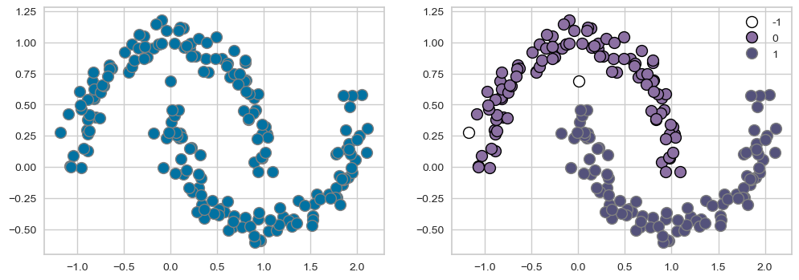

```python
X, y = make_moons(n_samples=200, noise=0.08, random_state=42)
dbscan = DBSCAN(eps=0.2)
dbscan.fit(X)
plot_X_dbscan(X, dbscan)
```

```python
dbscan.labels_
```

```
array([ 0,  0,  0,  1,  1,  1,  0,  1,  1,  0,  0,  1,  1,  0,  1,  1,  0,
        1,  0,  0,  1,  0,  1,  0,  0,  0,  0,  0,  1,  1,  0,  0,  0,  0,
        1,  1,  1,  1,  1,  0,  0,  1,  0,  0,  1,  1,  0,  0,  1,  0,  1,
        1,  0,  1,  1,  0,  1,  0,  1,  0,  1,  0,  0,  0,  0,  1,  0,  1,
        0,  1,  0,  1,  1,  0,  1,  1,  0,  1, -1,  1,  0,  0,  0,  1,  1,
        0,  1,  0,  1,  0,  0,  1,  1,  0,  0,  1,  1,  0,  0,  1,  0,  0,
        1,  1,  1,  1,  0,  0,  1,  1,  1,  0,  1,  1,  0,  1,  0,  0,  1,
        0,  0,  1,  1,  1,  0,  0,  1,  1,  0,  0,  1,  0,  0,  1,  0,  1,
        0,  1,  0,  1,  1,  1,  1,  0,  0,  0,  0,  1,  0,  0,  1,  1,  0,
        0,  0,  0,  1,  1,  0,  0,  1,  1,  1,  1,  0,  0,  1,  0,  1,  0,
        0,  0,  0,  0,  1,  1,  1,  0,  1,  1,  0,  0,  1,  1,  1,  1,  0,
        1,  0,  0,  1,  1,  0,  1,  0,  1,  0, -1,  1,  1], dtype=int64)
```

- DBSCAN is able to capture half moons shape
- We don't have to specify the number of clusters.
  - That said, it has two other non-trivial hyperparameters to tune.
- There are two examples which have not been assigned any label (noise examples).

One more example of DBSCAN clusters capturing complex cluster shapes.

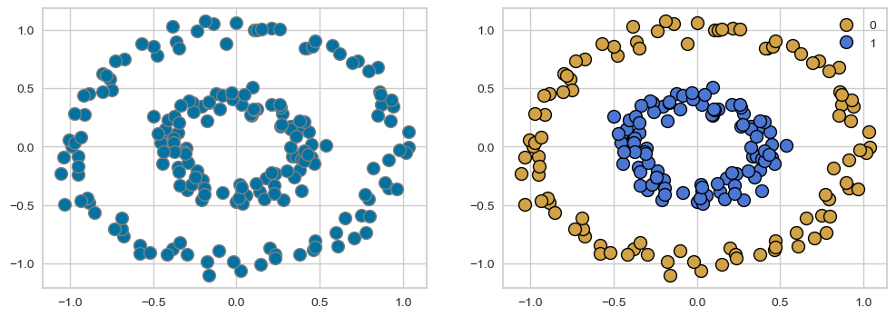

```python
X = datasets.make_circles(n_samples=200, noise=0.06, factor=0.4)[0]
dbscan = DBSCAN(eps=0.3, min_samples=3)
dbscan.fit(X)
plot_X_dbscan(X, dbscan)
```

### How does it work?

- Iterative algorithm.
- Based on the idea that clusters form dense regions in the data.

[figure not shown]

[Source](https://dashee87.github.io/data%20science/general/Clustering-with-Scikit-with-GIFs/)

### Two main hyperparameters

- `eps`: determines what it means for points to be "close"
- `min_samples`: determines the number of **neighboring points** we require to consider in order for a point to be part of a cluster

### Effect of `eps` hyperparameter

- `eps`: determines what it means for points to be "close"

```python
X, y = make_blobs(random_state=0, n_samples=11)
interactive(lambda eps=1: plot_dbscan_with_labels(X, eps), eps=(1, 12, 1))
```

```python
pd.DataFrame(euclidean_distances(X, X)).round()
```

|  | 0 | 1 | 2 | 3 | 4 | 5 | 6 | 7 | 8 | 9 | 10 |
| --- | --- | --- | --- | --- | --- | --- | --- | --- | --- | --- | --- |
| 0 | 0.0 | 4.0 | 0.0 | 4.0 | 1.0 | 4.0 | 3.0 | 1.0 | 3.0 | 3.0 | 4.0 |
| 1 | 4.0 | 0.0 | 4.0 | 5.0 | 6.0 | 4.0 | 3.0 | 5.0 | 1.0 | 4.0 | 1.0 |
| 2 | 0.0 | 4.0 | 0.0 | 4.0 | 2.0 | 4.0 | 3.0 | 1.0 | 3.0 | 3.0 | 4.0 |
| 3 | 4.0 | 5.0 | 4.0 | 0.0 | 4.0 | 2.0 | 3.0 | 3.0 | 4.0 | 1.0 | 5.0 |
| 4 | 1.0 | 6.0 | 2.0 | 4.0 | 0.0 | 5.0 | 4.0 | 1.0 | 5.0 | 4.0 | 6.0 |
| 5 | 4.0 | 4.0 | 4.0 | 2.0 | 5.0 | 0.0 | 1.0 | 3.0 | 3.0 | 1.0 | 3.0 |
| 6 | 3.0 | 3.0 | 3.0 | 3.0 | 4.0 | 1.0 | 0.0 | 3.0 | 2.0 | 2.0 | 2.0 |
| 7 | 1.0 | 5.0 | 1.0 | 3.0 | 1.0 | 3.0 | 3.0 | 0.0 | 4.0 | 3.0 | 5.0 |
| 8 | 3.0 | 1.0 | 3.0 | 4.0 | 5.0 | 3.0 | 2.0 | 4.0 | 0.0 | 3.0 | 1.0 |
| 9 | 3.0 | 4.0 | 3.0 | 1.0 | 4.0 | 1.0 | 2.0 | 3.0 | 3.0 | 0.0 | 4.0 |
| 10 | 4.0 | 1.0 | 4.0 | 5.0 | 6.0 | 3.0 | 2.0 | 5.0 | 1.0 | 4.0 | 0.0 |

### Effect of `min_samples` hyperparameter

```python
interactive(
    lambda min_samples=1: plot_dbscan_with_labels(X, eps=2.0, min_samples=min_samples),
    min_samples=(1, 5, 1),
)
```

### More details on DBSCAN

There are three kinds of points.

- **Core points** are the points that have at least `min_samples` points within a distance of `eps`
- **Border points** are connected to a core point. They are within a distance of eps to core point but they have fewer than `min_samples` points within a distance of `eps`.
- **Noise points** are the points which do not belong to any cluster. In other words, the points which have less than `min_samples` points within distance `eps` of the starting point are noise points.

### DBSCAN algorithm

- Pick a point $p$ at random.
- Check whether $p$ is a "core" point or not. You can check this by looking at the number of neighbours within epsilon distance if they have at least `min_samples` points in the neighbourhood
- If $p$ is a core point, give it a colour (label).
- Spread the colour of $p$ to all of its neighbours.
- Check if any of the neighbours that received the colour is a core point, if yes, spread the colour to its neighbors as well.
- Once there are no more core points left to spread the colour, pick a new unlabeled point $p$ and repeat the process.

### K-Means vs. DBSCAN

- In DBSCAN, you do not have to specify the number of clusters!
  - Instead, you have to tune `eps` and `min_samples`.
- Unlike K-Means, DBSCAN doesn't have to assign all points to clusters.
  - The label is -1 if a point is unassigned.
- Unlike K-Means, there is no `predict` method.
  - DBSCAN only really clusters the points you have, not "new" or "test" points.

### Illustration of hyperparameters `eps` and `min_samples`

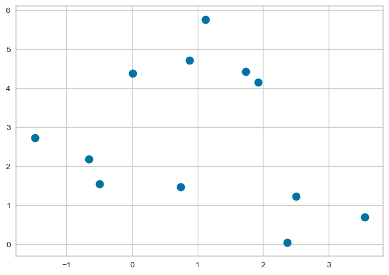

```python
X, y = make_blobs(random_state=0, n_samples=12)
mglearn.discrete_scatter(X[:, 0], X[:, 1]);
```

```python
dbscan = DBSCAN()
clusters = dbscan.fit_predict(X)
print("Cluster memberships:{}".format(clusters))
```

```
Cluster memberships:[-1 -1 -1 -1 -1 -1 -1 -1 -1 -1 -1 -1]
```

- Default values for hyperparameters don't work well on toy datasets.
- All points have been marked as noise with the default values for `eps` and `min_samples`
- Let's examine the effect of changing these hyperparameters.
  - noise points: shown in white
  - core points: bigger
  - border points: smaller

```
min_samples: 2 eps: 1.000000  cluster: [-1  0  0 -1  0 -1  1  1  0  1 -1 -1]
min_samples: 2 eps: 1.500000  cluster: [0 1 1 1 1 0 2 2 1 2 2 0]
min_samples: 2 eps: 2.000000  cluster: [0 1 1 1 1 0 0 0 1 0 0 0]
min_samples: 2 eps: 3.000000  cluster: [0 0 0 0 0 0 0 0 0 0 0 0]
min_samples: 3 eps: 1.000000  cluster: [-1  0  0 -1  0 -1  1  1  0  1 -1 -1]
min_samples: 3 eps: 1.500000  cluster: [0 1 1 1 1 0 2 2 1 2 2 0]
min_samples: 3 eps: 2.000000  cluster: [0 1 1 1 1 0 0 0 1 0 0 0]
min_samples: 3 eps: 3.000000  cluster: [0 0 0 0 0 0 0 0 0 0 0 0]
min_samples: 5 eps: 1.000000  cluster: [-1 -1 -1 -1 -1 -1 -1 -1 -1 -1 -1 -1]
min_samples: 5 eps: 1.500000  cluster: [-1  0  0  0  0 -1 -1 -1  0 -1 -1 -1]
min_samples: 5 eps: 2.000000  cluster: [-1  0  0  0  0 -1 -1 -1  0 -1 -1 -1]
min_samples: 5 eps: 3.000000  cluster: [0 0 0 0 0 0 0 0 0 0 0 0]
```

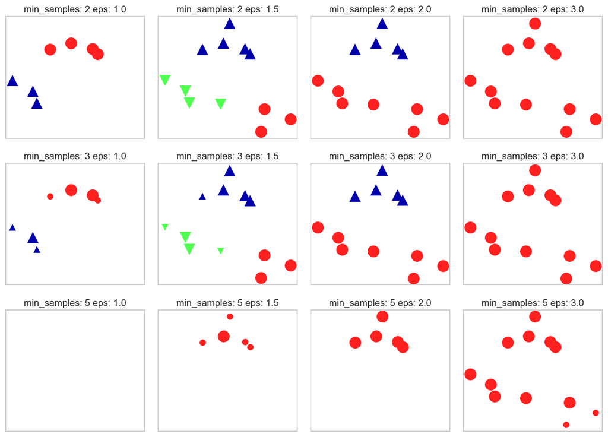

```python
mglearn.plots.plot_dbscan()
```

### Observations

- Increasing `eps` ($\uparrow$) (left to right in the plot above) means more points will be included in a cluster.
  - `eps` = 1.0 either creates more clusters or more noise points, whereas eps=3.0 puts all points in one cluster with no noise points.
- Increasing `min_samples` ($\uparrow$) (top to bottom in the plot above) means points in less dense regions will either be labeled as their own cluster or noise.
  - `min_samples=2`, for instance, has none or only a fewer noise points whereas `min_samples=5` has several noise points.
- Here `min_samples` = 2.0 or 3.0 and `eps` = 1.5 is giving us the best results.
- In general, it's not trivial to tune these hyperparameters.

### Question for you

- Does the order that you pick the points matter in DBSCAN?

> No. Any of the cluster's core points is able to fully identify the cluster, with no randomness involved. The only possible conflict you might get is that if two clusters have the same border point. In this case the assignment will be implementation dependent, but usually the border point will be assigned to the first cluster that "finds" it.

### Evaluating DBSCAN clusters

- We cannot use the elbow method to examine the goodness of clusters created with DBSCAN.
- But we can use the silhouette method because it's not dependent on the idea of cluster centers.

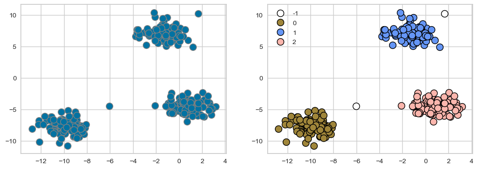

```python
X, y = make_blobs(random_state=100, centers=3, n_samples=300)
dbscan = DBSCAN(eps=2, min_samples=5)
dbscan.fit(X)
plot_X_dbscan(X, dbscan)
```

```python
# Yellowbrick is designed to work with K-Means and not with DBSCAN.
# So it needs the number of clusters stored in n_clusters
# It also needs `predict` method to be implemented.
# So I'm implementing it here so that we can use Yellowbrick to show Silhouette plots.
n_clusters = len(set(dbscan.labels_))
dbscan.n_clusters = n_clusters
dbscan.predict = lambda x: dbscan.labels_
```

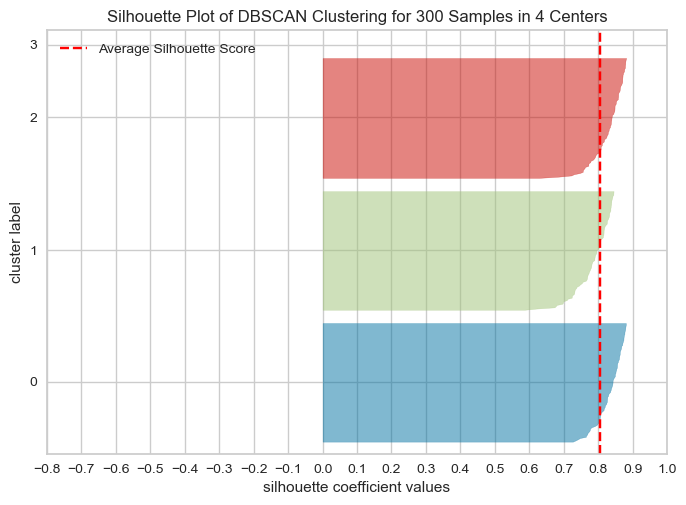

```python
visualizer = SilhouetteVisualizer(dbscan, colors="yellowbrick")
visualizer.fit(X)  # Fit the data to the visualizer
visualizer.show();
```

### Summary: Pros and cons

- Pros
  - Can learn arbitrary cluster shapes
  - Can detect outliers
- Cons
  - Cannot `predict` on new examples.
  - Needs tuning of two non-obvious hyperparameters

There is an improved version of DBSCAN called [`HDBSCAN` (hierarchical DBSCAN)](https://github.com/scikit-learn-contrib/hdbscan).

### DBSCAN: failure cases

- DBSCAN is able to capture complex clusters. But this doesn't mean that `DBSCAN` always works better. It has its own problems!
- DBSCAN doesn't do well when we have clusters with different densities.
  - You can play with the hyperparameters but it's not likely to help much.

### DBSCAN: failure cases

- Let's consider this dataset with three clusters of varying densities.
- K-Means performs better compared to DBSCAN. But it has the benefit of knowing the value of $K$ in advance.

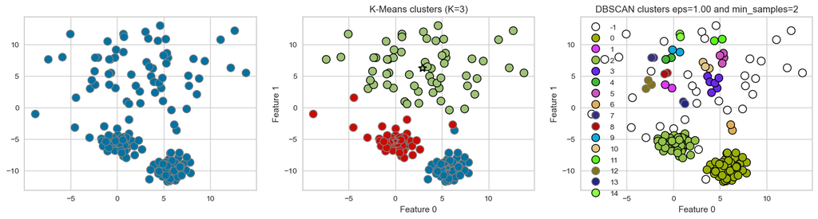

```python
X_varied, y_varied = make_blobs(
    n_samples=200, cluster_std=[1.0, 5.0, 1.0], random_state=10
)
plot_k_means_dbscan_comparison(X_varied)
```

## Hierarchical clustering

### Motivation

- Deciding how many clusters we want is a hard problem.
- Often, it's useful to get a complete picture of similarity between points in our data before picking the number of clusters.
- Hierarchical clustering is helpful in these scenarios.

### Main idea

1. Start with each point in its own cluster.
2. Greedily merge most similar *clusters*.
3. Repeat Step 2 until you obtain only one cluster ($n-1$ times).

### Visualizing hierarchical clustering

- Hierarchical clustering can be visualized using a tool called **a dendrogram**.
- Unfortunately, `sklearn` cannot do it so we will use the package `scipy.cluster.hierarchy` for hierarchical clustering.

### Hierarchical clustering input and output

```python
X, y = make_blobs(random_state=0, n_samples=11)
linkage_array = ward(X)
```

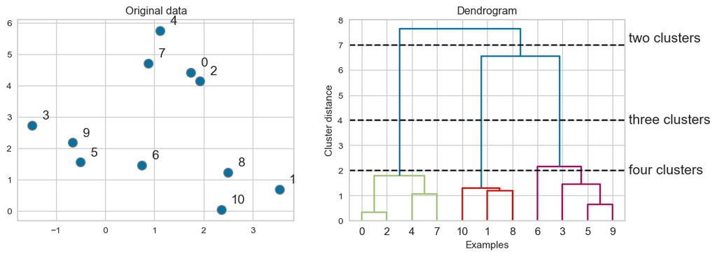

```python
plot_X_dendrogram(X, linkage_array, label_n_clusters=True)
```

- Every point goes through the journey of being on its own (its own cluster) and getting merged with some other bigger clusters.
- The intermediate steps in the process provide us clustering with different number of clusters.

### Dendrogram

- Dendrogram is a tree-like plot.
- On the x-axis we have data points.
- On the y-axis we have distances between clusters.
- We start with data points as leaves of the tree.
- New parent node is created for every two clusters that are joined.
- The length of each branch shows how far the merged clusters go.
  - In the dendrogram above going from three clusters to two clusters means merging far apart points because the branches between three cluster to two clusters are long.

### How to plot a dendrogram?

```python
from scipy.cluster.hierarchy import dendrogram

ax = plt.gca()
dendrogram(linkage_array, ax=ax)
plt.xlabel("Sample index")
plt.ylabel("Cluster distance");
```

[output not shown]

### What do we mean by distance between clusters?

- We know how to measure distance between points (e.g., using Euclidean distance).
- How do we measure distances between clusters?
- The **linkage criteria** determines how to find similarity between clusters:
- Some example linkage criteria are:
  - single linkage (minimum distance)
  - average linkage (average distance)
  - complete (or maximum) linkage (maximum distance)
  - ward linkage

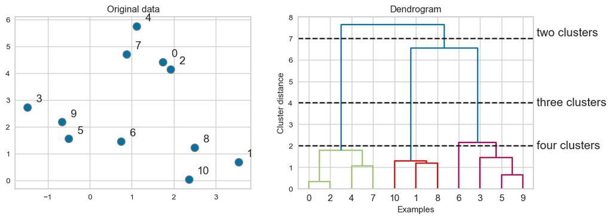

```python
plot_X_dendrogram(X, linkage_array, label_n_clusters=True)
```

### `single` linkage

- Merges two clusters that have the smallest minimum distance between all their points.
- Let's use `scipy.cluster.hierarchy`'s `single` to get linkage information.
- This method gives us matrix `Z` with the merging information.

```python
from scipy.cluster.hierarchy import (
    average,
    complete,
    dendrogram,
    fcluster,
    single,
    ward,
)

Z = single(X)
columns = ["c1", "c2", "distance(c1, c2)", "# observations"]
```

```python
pd.DataFrame(Z, columns=columns).head()
```

|  | c1 | c2 | distance(c1, c2) | # observations |
| --- | --- | --- | --- | --- |
| 0 | 0.0 | 2.0 | 0.332095 | 2.0 |
| 1 | 5.0 | 9.0 | 0.645802 | 2.0 |
| 2 | 7.0 | 11.0 | 0.911272 | 3.0 |
| 3 | 3.0 | 12.0 | 0.989059 | 3.0 |
| 4 | 4.0 | 13.0 | 1.072565 | 4.0 |

- The linkage returns a matrix `Z` of shape n-1 by 4:
- The rows represent iterations.
- First and second columns (c1 and c2 above): indexes of the clusters being merged.
- Third column (distance(c1, c2)): the distance between the clusters being merged.
- Fourth column (# observations): the number of examples in the newly formed cluster.

### Creating dendrogram with `single` linkage

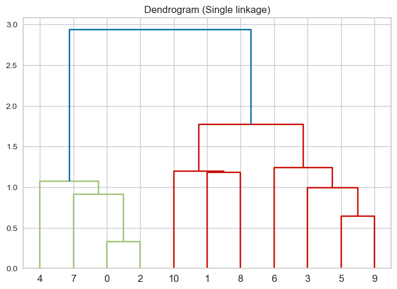

```python
dendrogram(Z)
# Z is our single linkage matrix
plt.title("Dendrogram (Single linkage)");
```

### `average` linkage

- Merges two clusters that have the smallest average distance between all their points.
- `scipy.cluster.hierarchy`'s `average` method gives us matrix `Z` with the merging information using average linkage.

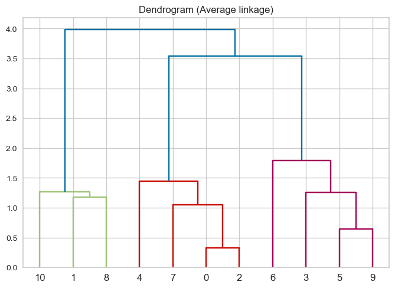

```python
Z = average(X)
dendrogram(Z)
# Dendrogram with average linkage
plt.title("Dendrogram (Average linkage)");
```

### `complete` linkage

- Merges two clusters that have the smallest maximum distance between their points.

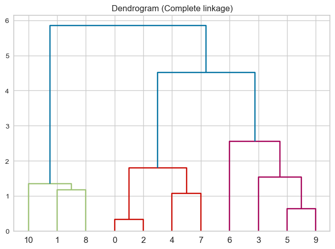

```python
Z = complete(X)
dendrogram(Z)
# Dendrogram with complete linkage
plt.title("Dendrogram (Complete linkage)");
```

### `ward` linkage

- Picks two clusters to merge such that the variance within all clusters increases the least.
- Often leads to equally sized clusters.

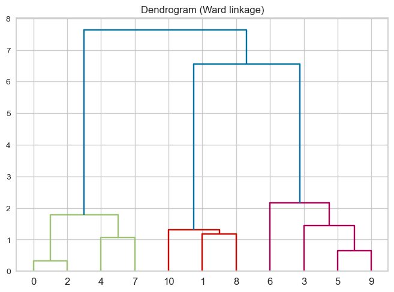

```python
Z = ward(X)
dendrogram(Z)
# Dendrogram with ward linkage
plt.title("Dendrogram (Ward linkage)");
```

### Hierarchical clustering on UN Subvotes dataset

- Let's use a dataset of votes on UN resolutions:

```python
votes_df = pd.read_csv("data/subvotes.csv")
votes = votes_df.pivot(index="country", columns="rcid")
votes = votes[np.sum(np.isnan(votes), axis=1) < 1]
print(votes.shape)
votes.head()
```

```
(17, 368)
```

| rcid country | vote 2491 | vote 2492 | vote 2497 | vote 2504 | vote 2510 | vote 2526 | vote 2563 | vote 2610 | vote 2641 | vote 2645 | vote ... | vote 5321 | vote 5333 | vote 5337 | vote 5358 | vote 5363 | vote 5364 | vote 5365 | vote 5367 | vote 5383 | vote 5385 |
| --- | --- | --- | --- | --- | --- | --- | --- | --- | --- | --- | --- | --- | --- | --- | --- | --- | --- | --- | --- | --- | --- |
| Australia | 1.0 | 2.0 | 1.0 | 3.0 | 3.0 | 3.0 | 1.0 | 1.0 | 1.0 | 1.0 | ... | 1.0 | 1.0 | 1.0 | 1.0 | 2.0 | 1.0 | 3.0 | 1.0 | 3.0 | 3.0 |
| Austria | 1.0 | 1.0 | 1.0 | 2.0 | 2.0 | 2.0 | 1.0 | 1.0 | 1.0 | 1.0 | ... | 1.0 | 1.0 | 1.0 | 1.0 | 2.0 | 2.0 | 2.0 | 1.0 | 3.0 | 3.0 |
| Brazil | 1.0 | 1.0 | 1.0 | 1.0 | 1.0 | 2.0 | 2.0 | 3.0 | 1.0 | 1.0 | ... | 1.0 | 1.0 | 1.0 | 1.0 | 1.0 | 1.0 | 1.0 | 1.0 | 1.0 | 1.0 |
| Colombia | 1.0 | 1.0 | 1.0 | 1.0 | 1.0 | 2.0 | 1.0 | 2.0 | 1.0 | 1.0 | ... | 1.0 | 1.0 | 1.0 | 1.0 | 1.0 | 1.0 | 1.0 | 1.0 | 1.0 | 1.0 |
| Denmark | 1.0 | 1.0 | 1.0 | 2.0 | 2.0 | 3.0 | 1.0 | 1.0 | 1.0 | 1.0 | ... | 1.0 | 1.0 | 1.0 | 1.0 | 2.0 | 2.0 | 2.0 | 1.0 | 3.0 | 3.0 |

5 rows × 368 columns

- We have 17 countries and 368 votes.
- Let's cluster countries based on how they vote.
- We'll use [hamming distance](https://en.wikipedia.org/wiki/Hamming_distance) here because we are interested in knowing whether the countries agreed or disagreed on resolutions.

```python
def plot_dendrogram(method="average", metric="hamming", w=22, h=12):
    Z = linkage(votes, method=method, metric=metric)
    fig, ax = plt.subplots(figsize=(w, h))
    dendrogram(Z, labels=votes.index, ax=ax)
    ax = plt.gca()
    ax.set_ylabel("Distance", fontsize=w)
    ax.set_xticklabels(ax.get_xticklabels(), rotation=80, fontsize=w)
```

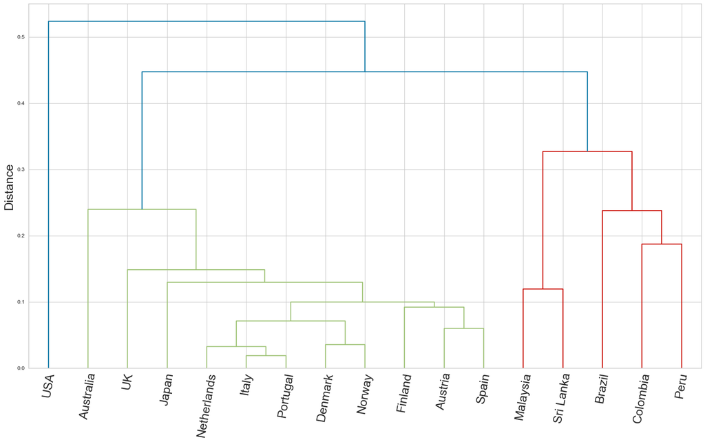

```python
plot_dendrogram()
```

### Truncation

- If you want to truncate the tree in the dendrogram (specially when you have a big $n$) you can use the `truncate_mode`.

[output not shown]

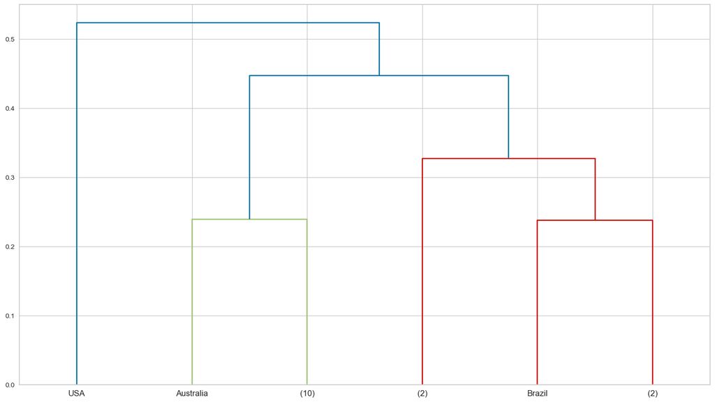

```python
Z = linkage(votes, method="average", metric="hamming")
fig, ax = plt.subplots(figsize=(18, 10))
dendrogram(Z, p=6, truncate_mode="lastp", ax=ax, labels=votes.index)
# p is the number of leaves when truncate mode is "lastp"
```

- Alternatively, you can truncate the tree down to $x$ levels from the single cluster:

[output not shown]

[output cut: 17 more lines]

[output not shown]

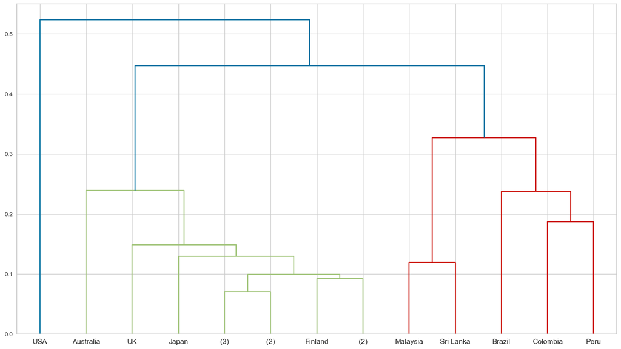

```python
fig, ax = plt.subplots(figsize=(18, 10))
dendrogram(Z, p=6, truncate_mode="level", ax=ax, labels=votes.index)
# p is the max depth of the tree when truncate_mode is "level"
```

Let's go back to our toy dataset to understand truncation better.

```python
ax = plt.gca()
dendrogram(linkage_array, ax=ax)
plt.xlabel("Sample index")
plt.ylabel("Cluster distance");
```

[output not shown]

[output not shown]

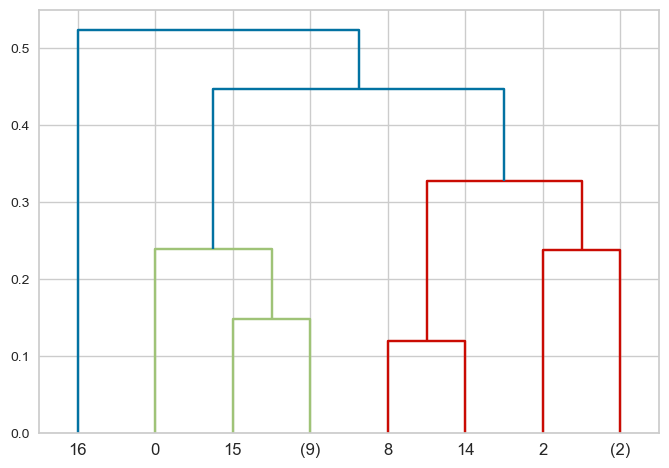

```python
dendrogram(Z, p=3, truncate_mode="level")
# p is the max depth of the tree
```

```
{'icoord': [[25.0, 25.0, 35.0, 35.0],
  [15.0, 15.0, 30.0, 30.0],
  [5.0, 5.0, 22.5, 22.5]],
 'dcoord': [[0.0, 0.3269927536231884, 0.3269927536231884, 0.0],
  [0.0, 0.44738142292490124, 0.44738142292490124, 0.3269927536231884],
  [0.0, 0.5237771739130435, 0.5237771739130435, 0.44738142292490124]],
 'ivl': ['16', '(11)', '(2)', '(3)'],
 'leaves': [16, 29, 24, 28],
 'color_list': ['C1', 'C0', 'C0'],
 'leaves_color_list': ['C0', 'C0', 'C1', 'C1']}
```

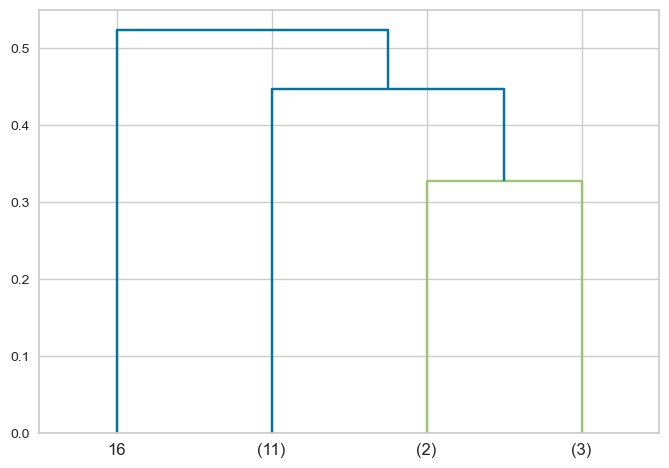

```python
dendrogram(Z, p=4, truncate_mode="lastp")
# p is the number of leaf nodes
```

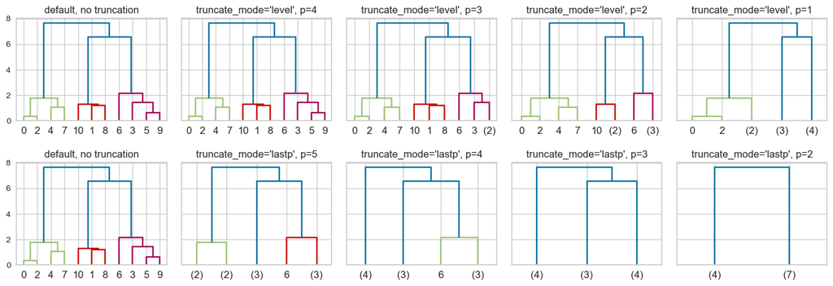

```python
hc_truncation_toy_demo(linkage_array)
```

### Flat cluster

- To bring the clustering to a "flat" format, we can use `fcluster`

```python
from scipy.cluster.hierarchy import fcluster

cluster_labels = fcluster(Z, 6, criterion="maxclust")
```

```python
pd.DataFrame(cluster_labels, votes.index)
```

| country | 0 |
| --- | --- |
| Australia | 2 |
| Austria | 1 |
| Brazil | 5 |
| Colombia | 4 |
| Denmark | 1 |
| Finland | 1 |
| Italy | 1 |
| Japan | 1 |
| Malaysia | 3 |
| Netherlands | 1 |
| Norway | 1 |
| Peru | 4 |
| Portugal | 1 |
| Spain | 1 |
| Sri Lanka | 3 |
| UK | 1 |
| USA | 6 |

To understand this better, let's try it out on our toy dataset.

```python
ax = plt.gca()
dendrogram(linkage_array, ax=ax)
plt.xlabel("Sample index")
plt.ylabel("Cluster distance");
```

[output not shown]

```python
cluster_labels = fcluster(linkage_array, 3, criterion="maxclust")
pd.DataFrame(cluster_labels, columns=["Cluster"])
```

|  | Cluster |
| --- | --- |
| 0 | 1 |
| 1 | 2 |
| 2 | 1 |
| 3 | 3 |
| 4 | 1 |
| 5 | 3 |
| 6 | 3 |
| 7 | 1 |
| 8 | 2 |
| 9 | 3 |
| 10 | 2 |

## ❓❓ Questions for you

**Select all of the following statements which are TRUE.**

- (A) With tiny epsilon (`eps` in `sklearn`) and min samples=1 (`min_samples=1` in `sklearn`) we are likely to end up with each point in its own cluster.
- (B) With a smaller value of `eps` and larger number for `min_samples` we are likely to end up with a one big cluster.
- (C) K-Means is more susceptible to outliers compared to DBSCAN.
- (D) In DBSCAN to be part of a cluster, each point must have at least `min_samples` neighbours in a given radius (including itself).
- (E) In DBSCAN, we could randomize the order in which the training examples are processed by the algorithm. It is generally a good idea to run DBSCAN with a large number of different random orderings.

**Select all of the following statements which are TRUE.**

- (A) In hierarchical clustering we do not have to worry about initialization.
- (B) Hierarchical clustering can only be applied to smaller datasets because dendrograms are hard to visualize for large datasets.
- (C) In all the three clustering methods we saw (K-Means, DBSCAN, hierarchical clustering), there is a way to decide the granularity of clustering (i.e., how many clusters to pick).
- (D) To get robust clustering we can naively ensemble cluster labels (e.g., pick the most popular label) produced by different clustering methods.
- (E) If you have a high Silhouette score and very clean and robust clusters, it means that the algorithm has captured the semantic meaning in the data of our interest.

## Applying clustering on face images

- We'll be working with `sklearn`'s [Labeled Faces in the Wild dataset](https://scikit-learn.org/0.16/datasets/labeled_faces.html).
- The dataset has images of celebrities from the early 2000s downloaded from the internet.

> Credit: This example is based on the example from [here](https://learning.oreilly.com/library/view/introduction-to-machine/9781449369880/ch03.html).

### Example images from the dataset

```python
people = fetch_lfw_people(min_faces_per_person=20, resize=0.7)

fig, axes = plt.subplots(2, 5, figsize=(10, 5), subplot_kw={"xticks": (), "yticks": ()})
for target, image, ax in zip(people.target, people.images, axes.ravel()):
    ax.imshow(image)
    ax.set_title(people.target_names[target])
```

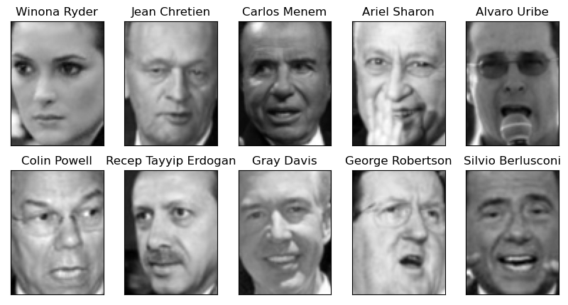

```python
plt.show()
```

```python
image_shape = people.images[0].shape
print("people.images.shape: {}".format(people.images.shape))
print("Number of classes: {}".format(len(people.target_names)))
```

```
people.images.shape: (3023, 87, 65)
Number of classes: 62
```

There are 3,023 images stored as arrays of 5655 pixels (87 by 65), of 62 different people:

```python
counts = np.bincount(people.target)  # count how often each target appears
df = pd.DataFrame(counts, columns=["count"], index=people.target_names)
df.sort_values("count", ascending=False)
```

|  | count |
| --- | --- |
| George W Bush | 530 |
| Colin Powell | 236 |
| Tony Blair | 144 |
| Donald Rumsfeld | 121 |
| Gerhard Schroeder | 109 |
| ... | ... |
| Angelina Jolie | 20 |
| Jiang Zemin | 20 |
| Paul Bremer | 20 |
| Igor Ivanov | 20 |
| Michael Bloomberg | 20 |

62 rows × 1 columns

Let's make the data less skewed by taking only 20 images of the each person.

```python
mask = np.zeros(people.target.shape, dtype=np.bool)
for target in np.unique(people.target):
    mask[np.where(people.target == target)[0][:20]] = 1

X_people = people.data[mask]
y_people = people.target[mask]
```

```python
X_people.shape
```

```
(1240, 5655)
```

```python
# scale the grayscale values to be between 0 and 1
# instead of 0 and 255 for better numeric stability
X_people = X_people / 255.0
```

### Representation of images

- Representation of input is very important when you cluster examples.
- In this example, we'll use PCA representation.

```python
from sklearn.decomposition import PCA

pca = PCA(n_components=100, whiten=True, random_state=0)
X_pca = pca.fit_transform(X_people)
```

### Clustering faces with K-Means

We'll cluster the images with this new representation.

```python
km = KMeans(n_clusters=10, random_state=10)
km.fit(X_pca)
```

```
KMeans(n_clusters=10, random_state=10)
```

What are the sizes of the clusters?

```python
labels_km = km.fit_predict(X_pca)
print("Cluster sizes k-means: {}".format(np.bincount(labels_km)))
```

```
Cluster sizes k-means: [ 36 309  65 108  89  39  98 210 168 118]
```

Let's examine cluster centers. Are they going to be real images from the dataset?

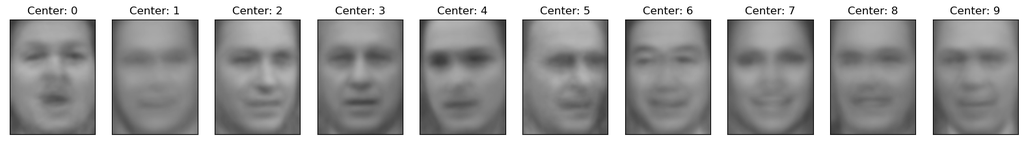

```python
plot_faces_cluster_centers(km, pca)
```

- The centers found by K-Means are smooth versions of faces which makes sense.
- Intuitively, they seem to capture some interesting characteristics of faces:
  - grumpy faces
  - faces somewhat rotated to the left/right
  - Smiley faces

Let's examine images for different centers.

```python
def get_cluster_images(km, X_people, y_people, target_names, X_pca=None, pca=None, cluster=0):
    image_shape = (87, 65)
    fig, axes = plt.subplots(1, 6, subplot_kw={'xticks': (), 'yticks': ()},
                             figsize=(10, 10), gridspec_kw={"hspace": .3})
    center = km.cluster_centers_[cluster]

    mask = km.labels_ == cluster

    if pca:
        dists = np.sum((X_pca - center) ** 2, axis=1)
        dists[~mask] = np.inf
        inds = np.argsort(dists)[:5]
        axes[0].imshow(pca.inverse_transform(center).reshape(image_shape), vmin=0, vmax=1)
    else:
        dists = np.sum((X_people - center) ** 2, axis=1)
        dists[~mask] = np.inf
        inds = np.argsort(dists)[:5]
        axes[0].imshow(center.reshape(image_shape), vmin=0, vmax=1)

    axes[0].set_title('Cluster center %d'%(cluster))
    i = 1
    for image, label in zip(X_people[inds], y_people[inds]):
        axes[i].imshow(image.reshape(image_shape), vmin=0, vmax=1)
        axes[i].set_title("%s" % (target_names[label].split()[-1]), fontdict={'fontsize': 9})
        i+=1
    plt.show()
```

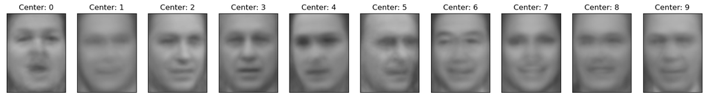

```python
plot_faces_cluster_centers(km, pca)
```

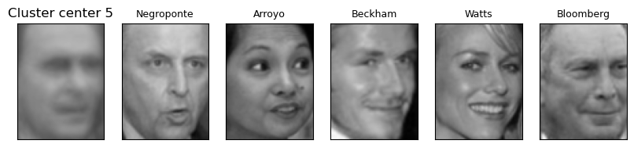

```python
get_cluster_images(
    km, X_people, y_people, people.target_names, pca=pca, X_pca=X_pca, cluster=5
)
```

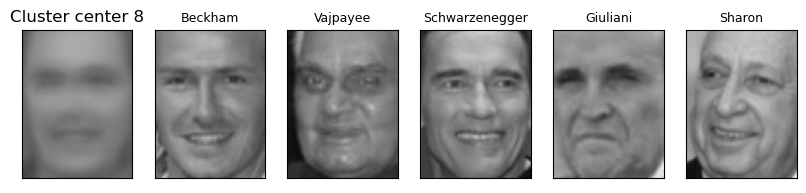

```python
get_cluster_images(
    km, X_people, y_people, people.target_names, pca=pca, X_pca=X_pca, cluster=8
)
```

### Clustering faces with DBSCAN

```python
dbscan = DBSCAN()
labels = dbscan.fit_predict(X_pca)
print("Unique labels: {}".format(np.unique(labels)))
```

```
Unique labels: [-1]
```

With default hyperparameters, we get all points as noise points.

#### Tuning `eps`

```python
people.target_names[y_people].shape
```

```
(1240,)
```

Let's examine at distances between images.

```python
from sklearn.metrics.pairwise import euclidean_distances

dists = euclidean_distances(X_pca)
np.fill_diagonal(dists, np.inf)

dist_df = pd.DataFrame(
    dists, index=people.target_names[y_people], columns=people.target_names[y_people]
)

dist_df.iloc[10:20, 10:20]
```

|  | George W Bush | George W Bush | Nestor Kirchner | Jean Chretien | Bill Clinton | George W Bush | Carlos Menem | Alvaro Uribe | George W Bush | Colin Powell |
| --- | --- | --- | --- | --- | --- | --- | --- | --- | --- | --- |
| George W Bush | inf | 11.544740 | 10.258084 | 12.427365 | 12.644946 | 11.121599 | 13.138457 | 14.667102 | 15.530873 | 10.503787 |
| George W Bush | 11.544740 | inf | 10.303787 | 13.642818 | 14.271929 | 11.599449 | 12.474016 | 15.075001 | 15.033504 | 11.432473 |
| Nestor Kirchner | 10.258084 | 10.303787 | inf | 10.842848 | 13.600067 | 10.531927 | 11.576270 | 14.146923 | 15.191011 | 8.954877 |
| Jean Chretien | 12.427365 | 13.642818 | 10.842848 | inf | 13.578986 | 13.103996 | 13.568855 | 16.059177 | 16.865265 | 11.750574 |
| Bill Clinton | 12.644946 | 14.271929 | 13.600067 | 13.578986 | inf | 14.232127 | 15.222546 | 16.806549 | 16.797367 | 14.481402 |
| George W Bush | 11.121599 | 11.599449 | 10.531927 | 13.103996 | 14.232127 | inf | 12.665558 | 15.961418 | 13.975029 | 11.810298 |
| Carlos Menem | 13.138457 | 12.474016 | 11.576270 | 13.568855 | 15.222546 | 12.665558 | inf | 16.289379 | 15.075190 | 10.978154 |
| Alvaro Uribe | 14.667102 | 15.075001 | 14.146923 | 16.059177 | 16.806549 | 15.961418 | 16.289379 | inf | 17.566322 | 14.859705 |
| George W Bush | 15.530873 | 15.033504 | 15.191011 | 16.865265 | 16.797367 | 13.975029 | 15.075190 | 17.566322 | inf | 15.792871 |
| Colin Powell | 10.503787 | 11.432473 | 8.954877 | 11.750574 | 14.481402 | 11.810298 | 10.978154 | 14.859705 | 15.792871 | inf |

```python
dist_df.describe()
```

|  | Winona Ryder | Jean Chretien | Carlos Menem | Ariel Sharon | Alvaro Uribe | Colin Powell | Recep Tayyip Erdogan | Gray Davis | George Robertson | Silvio Berlusconi | ... | Igor Ivanov | Hamid Karzai | Igor Ivanov | Jiang Zemin | Carlos Menem | Michael Bloomberg | Paul Bremer | Jiang Zemin | Paul Bremer | Igor Ivanov |
| --- | --- | --- | --- | --- | --- | --- | --- | --- | --- | --- | --- | --- | --- | --- | --- | --- | --- | --- | --- | --- | --- |
| count | 1240.000000 | 1240.000000 | 1240.000000 | 1240.000000 | 1240.000000 | 1240.000000 | 1240.000000 | 1240.000000 | 1240.000000 | 1240.000000 | ... | 1240.000000 | 1240.000000 | 1240.000000 | 1240.000000 | 1240.000000 | 1240.000000 | 1240.000000 | 1240.000000 | 1240.000000 | 1240.000000 |
| mean | inf | inf | inf | inf | inf | inf | inf | inf | inf | inf | ... | inf | inf | inf | inf | inf | inf | inf | inf | inf | inf |
| std | NaN | NaN | NaN | NaN | NaN | NaN | NaN | NaN | NaN | NaN | ... | NaN | NaN | NaN | NaN | NaN | NaN | NaN | NaN | NaN | NaN |
| min | 10.798938 | 9.188444 | 10.955708 | 10.340684 | 10.586757 | 7.991095 | 10.084944 | 12.265064 | 8.269720 | 8.073894 | ... | 9.934305 | 16.630968 | 7.218451 | 9.620404 | 8.732929 | 8.432666 | 10.796838 | 9.316413 | 11.808154 | 9.981050 |
| 25% | 13.646842 | 12.039103 | 13.315298 | 13.102975 | 13.116848 | 11.132258 | 12.571792 | 14.653528 | 12.655004 | 11.025032 | ... | 12.594153 | 18.882252 | 10.212042 | 13.110563 | 11.774527 | 11.506839 | 13.497952 | 12.350001 | 14.300526 | 13.190878 |
| 50% | 14.483324 | 12.964632 | 14.130376 | 14.024135 | 14.020585 | 12.102513 | 13.433448 | 15.451765 | 13.495023 | 11.960474 | ... | 13.427205 | 19.615462 | 11.292739 | 13.960775 | 12.564601 | 12.429486 | 14.308198 | 13.208098 | 15.122143 | 14.033503 |
| 75% | 15.537406 | 14.091513 | 15.044789 | 15.091698 | 15.052525 | 13.347610 | 14.531173 | 16.457010 | 14.588345 | 13.204581 | ... | 14.521263 | 20.430767 | 12.572392 | 15.105677 | 13.666414 | 13.470039 | 15.386033 | 14.352139 | 16.177488 | 15.133169 |
| max | inf | inf | inf | inf | inf | inf | inf | inf | inf | inf | ... | inf | inf | inf | inf | inf | inf | inf | inf | inf | inf |

8 rows × 1240 columns

```python
for eps in [6, 7, 8, 9, 10, 11, 12, 14]:
    print("\neps={}".format(eps))
    dbscan = DBSCAN(eps=eps, min_samples=3)
    labels = dbscan.fit_predict(X_pca)
    print("Number of clusters: {}".format(len(np.unique(labels))))
    print("Cluster sizes: {}".format(np.bincount(labels + 1)))
```

```
eps=6
Number of clusters: 1
Cluster sizes: [1240]

eps=7
Number of clusters: 5
Cluster sizes: [1227    4    3    3    3]

eps=8
Number of clusters: 5
Cluster sizes: [1100  130    3    4    3]

eps=9
Number of clusters: 4
Cluster sizes: [841 393   3   3]

eps=10
Number of clusters: 2
Cluster sizes: [521 719]

eps=11
Number of clusters: 2
Cluster sizes: [282 958]

eps=12
Number of clusters: 2
Cluster sizes: [ 150 1090]

eps=14
Number of clusters: 2
Cluster sizes: [  45 1195]
```

- For lower `eps` all images are labeled as noise.
- For `eps=7` we get many noise points and many small clusters.
- For `eps=8` and `eps=9` we get many noise points but we also get one large cluster and a few smaller clusters.
- Starting `eps=10` we get one big cluster and noise points.
- There is never more than one large cluster suggesting that all the images are more or less equally similar/dissimilar to the rest.

#### Noise images identified by DBSCAN

```python
dbscan = DBSCAN(eps=14, min_samples=3)
labels = dbscan.fit_predict(X_pca)
print("Unique labels: {}".format(np.unique(labels)))
```

```
Unique labels: [-1  0]
```

```python
print_dbscan_noise_images(X_people, y_people, dbscan, labels)
```

[output not shown]

Let's examine DBSCAN clusters.

```python
dbscan = DBSCAN(min_samples=3, eps=7)
labels = dbscan.fit_predict(X_pca)
print("Number of clusters: {}".format(len(np.unique(labels))))
print("Cluster sizes: {}".format(np.bincount(labels + 1)))
```

```
Number of clusters: 5
Cluster sizes: [1227    4    3    3    3]
```

- Some clusters correspond to people with distinct faces and facial expressions.
- It's also capturing orientation of the face.

[figure not shown]

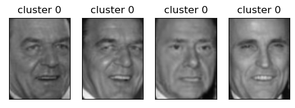

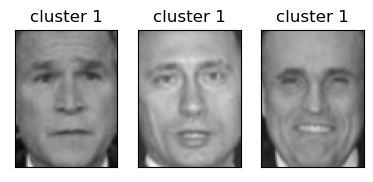

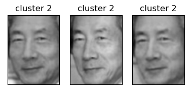

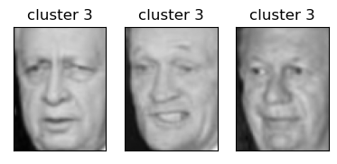

```python
print_dbscan_clusters(X_people, y_people, labels)
plt.show()
```